# Analyse des Correspondances Multiples

Jeu de données d

Ce jeu de données contient 416 individus et 57 variables, 19 variables quantitatives sont illustratives.

### 1. Observation d’individus extrêmes

L’analyse des graphes ne révèle aucun individu singulier.

### 2. Distribution de l’inertie

L’inertie des axes factoriels indique d’une part si les variables sont structurées et suggère d’autre part le nombre judicieux de composantes principales à étudier.

Les 2 premiers axes de l’ analyse expriment **12.09%** de l’inertie totale du jeu de données ; cela signifie que 12.09% de la variabilité totale du nuage des individus (ou des variables) est représentée dans ce plan. C’est un pourcentage très faible, et le premier plan ne représente donc seulement qu’une part de la variabilité contenue dans l’ensemble du jeu de données actif. Cette valeur est supérieure à la valeur référence de **9.72%**, la variabilité expliquée par ce plan est donc significative (cette intertie de référence est le quantile 0.95-quantile de la distribution des pourcentages d’inertie obtenue en simulant 1978 jeux de données aléatoires de dimensions comparables sur la base d’une distribution uniforme).

Du fait de ces observations, il serait alors certainement nécessaire de considérer également les dimensions supérieures ou égales à la troisième dans l’analyse.

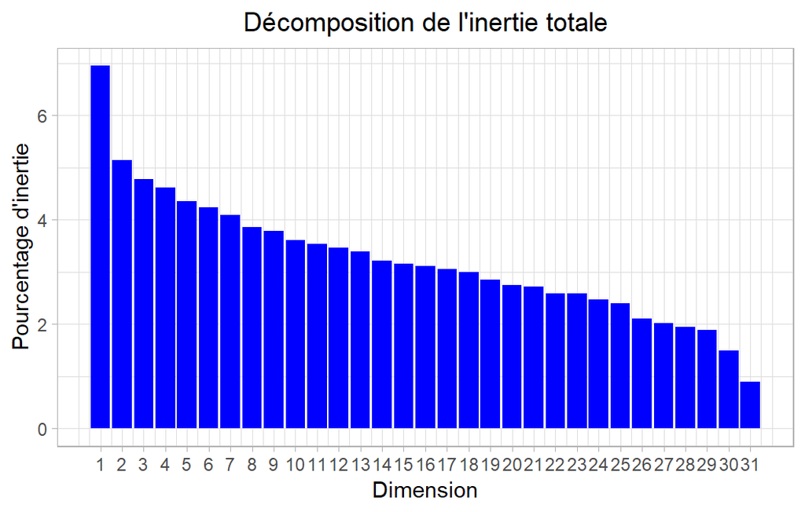

**Figure 2 - Décomposition de l’inertie totale**

Une estimation du nombre pertinent d’axes à interpréter suggère de restreindre l’analyse à la description des 7 premiers axes. Ces composantes révèlent un taux d’inertie supérieur à celle du quantile 0.95-quantile de distributions aléatoires (34.15% contre 30.97%). Cette observation suggère que seuls ces axes sont porteurs d’une véritable information. En conséquence, la description de l’analyse sera restreinte à ces seuls axes.

### 3. Description du plan 1:2

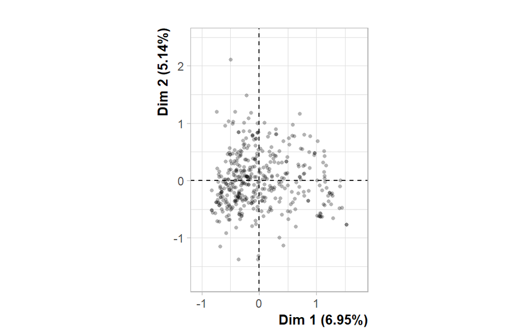

**Figure 3.1 - Graphe des individus (ACM)** *Les individus libellés sont ceux ayant la plus grande contribution à la construction du plan.*

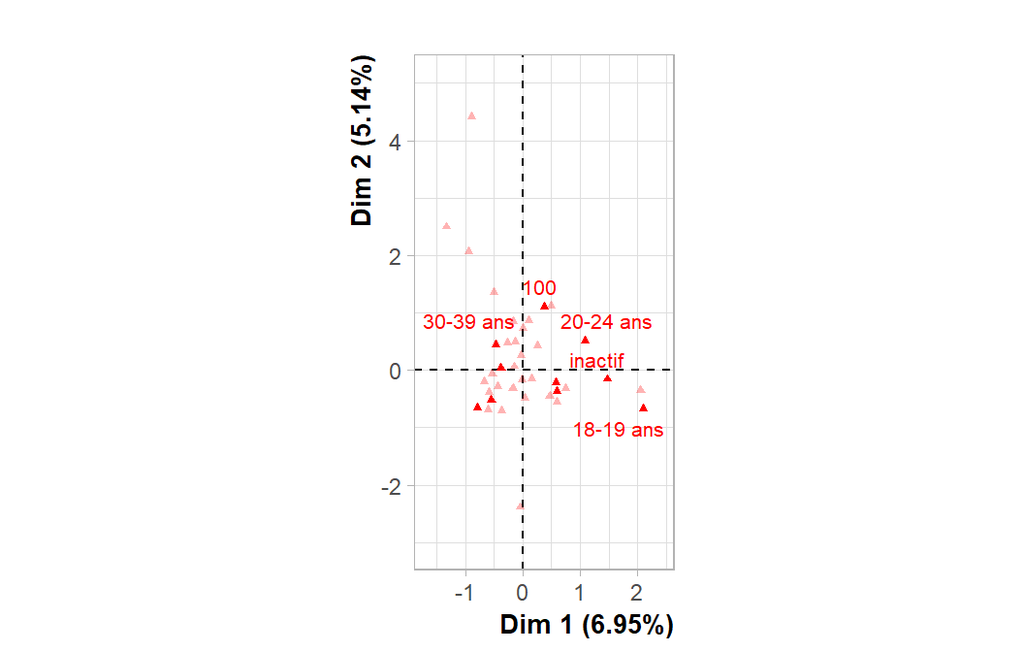

**Figure 3.2 - Graphe des variables (ACM)** *Les variables libellées sont celles les mieux représentées sur le plan.*

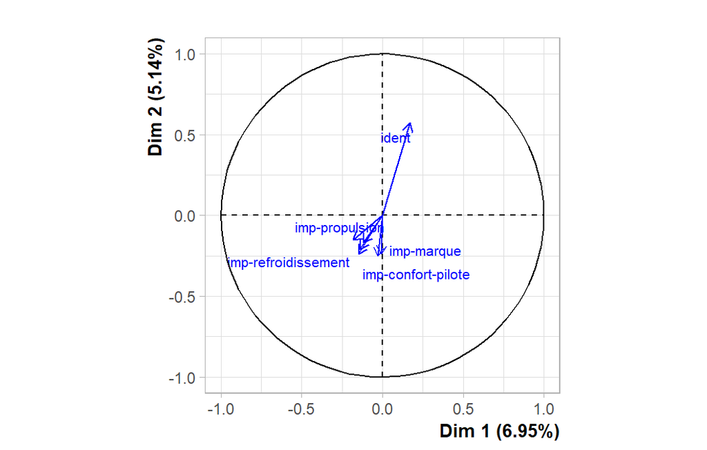

**Figure 3.3 - Graphe des variables quantitatives (ACM)** *Les variables libellées sont celles les mieux représentées sur le plan.*

La **dimension 1** oppose des individus caractérisés par une coordonnée fortement positive sur l’axe (à droite du graphe) à des individus caractérisés par une coordonnée fortement négative sur l’axe (à gauche du graphe).

Le groupe 1 (caractérisés par une coordonnée positive sur l’axe) partage :

- une forte fréquence des modalités telles que *CSP=inactif*, *type-utilisation=personnels et loisirs*, *âge=20-24 ans*, *âge=18-19 ans*, *type-cylindrée=125*, *sexe=femme*, *critère-esthétique=à la mode*, *type-cylindrée=100*, *critère-esthétique=sportif* et *note-satisfaction=8* (du plus commun au plus rare).
- une faible fréquence des modalités telles que *type-utilisation=domicile-travail*, *type-cylindrée=150-200*, *âge=40-49 ans*, *âge=30-39 ans*, *CSP=classe supérieure moyenne*, *sexe=homme*, *critère-esthétique=innovant nouveau*, *type-cylindrée=250-400*, *CSP=classe moyenne* et *âge=50 et +* (du plus rare au plus commun).

Le groupe 2 (caractérisés par une coordonnées négative sur l’axe) partage :

- une forte fréquence des modalités telles que *type-cylindrée=150-200*, *CSP=classe supérieure moyenne*, *type-cylindrée=250-400*, *critère-esthétique=innovant nouveau*, *âge=40-49 ans*, *type-utilisation=domicile-travail*, *âge=50 et +*, *CSP=classe moyenne*, *CSP=classe supérieure* et *note-satisfaction=9* (du plus commun au plus rare).
- une faible fréquence des modalités telles que *type-cylindrée=100*, *CSP=inactif*, *âge=20-24 ans*, *âge=18-19 ans*, *critère-esthétique=sportif*, *type-utilisation=personnels et loisirs*, *type-cylindrée=125*, *note-satisfaction=7*, *CSP=ouvrier* et *critère-esthétique=à la mode* (du plus rare au plus commun).

Le groupe 3 (caractérisés par une coordonnées négative sur l’axe) partage :

- une forte fréquence des modalités *type-cylindrée=100*, *âge=30-39 ans*, *CSP=employé*, *note-satisfaction=7*, *CSP=ouvrier*, *type-utilisation=professionnel*, *sexe=homme*, *type-utilisation=domicile-travail* et *critère-esthétique=discret / sobre* (du plus commun au plus rare).
- une faible fréquence des modalités *CSP=inactif*, *type-utilisation=personnels et loisirs*, *type-cylindrée=125*, *âge=20-24 ans*, *sexe=femme*, *type-cylindrée=250-400*, *âge=18-19 ans*, *note-satisfaction=8* et *CSP=classe supérieure moyenne* (du plus rare au plus commun).

La **dimension 2** oppose des individus caractérisés par une coordonnée fortement positive sur l’axe (en haut du graphe) à des individus caractérisés par une coordonnée fortement négative sur l’axe (en bas du graphe).

Le groupe 1 (caractérisés par une coordonnée positive sur l’axe) partage :

- une forte fréquence des modalités *type-cylindrée=100*, *âge=30-39 ans*, *CSP=employé*, *note-satisfaction=7*, *CSP=ouvrier*, *type-utilisation=professionnel*, *sexe=homme*, *type-utilisation=domicile-travail* et *critère-esthétique=discret / sobre* (du plus commun au plus rare).
- une faible fréquence des modalités *CSP=inactif*, *type-utilisation=personnels et loisirs*, *type-cylindrée=125*, *âge=20-24 ans*, *sexe=femme*, *type-cylindrée=250-400*, *âge=18-19 ans*, *note-satisfaction=8* et *CSP=classe supérieure moyenne* (du plus rare au plus commun).

Le groupe 2 (caractérisés par une coordonnées négative sur l’axe) partage :

- une forte fréquence des modalités telles que *type-cylindrée=150-200*, *CSP=classe supérieure moyenne*, *type-cylindrée=250-400*, *critère-esthétique=innovant nouveau*, *âge=40-49 ans*, *type-utilisation=domicile-travail*, *âge=50 et +*, *CSP=classe moyenne*, *CSP=classe supérieure* et *note-satisfaction=9* (du plus commun au plus rare).
- une faible fréquence des modalités telles que *type-cylindrée=100*, *CSP=inactif*, *âge=20-24 ans*, *âge=18-19 ans*, *critère-esthétique=sportif*, *type-utilisation=personnels et loisirs*, *type-cylindrée=125*, *note-satisfaction=7*, *CSP=ouvrier* et *critère-esthétique=à la mode* (du plus rare au plus commun).

### 4. Description du plan 3:4

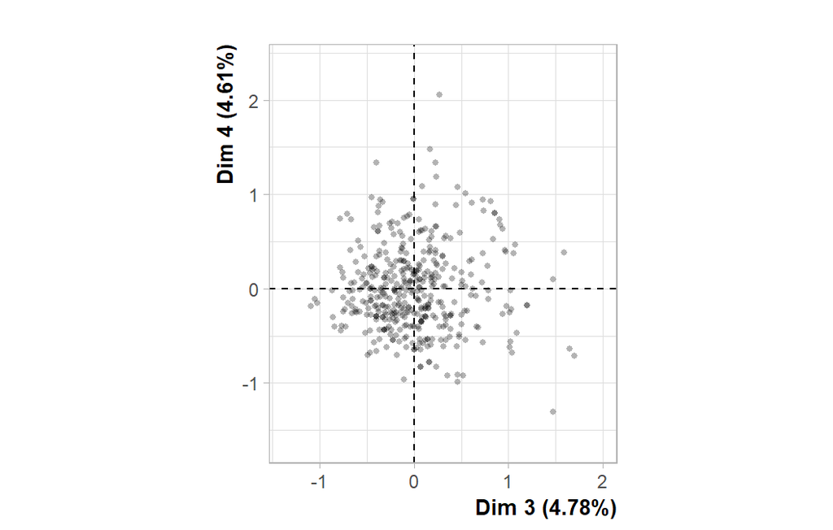

**Figure 4.1 - Graphe des individus (ACM)** *Les individus libellés sont ceux ayant la plus grande contribution à la construction du plan.*

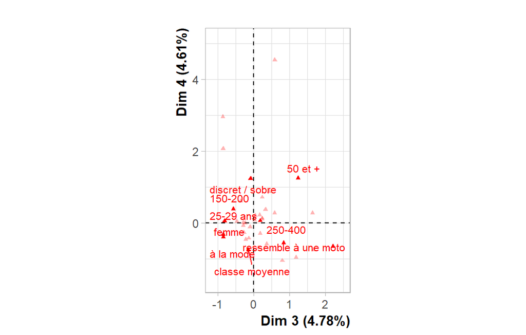

**Figure 4.2 - Graphe des variables (ACM)** *Les variables libellées sont celles les mieux représentées sur le plan.*

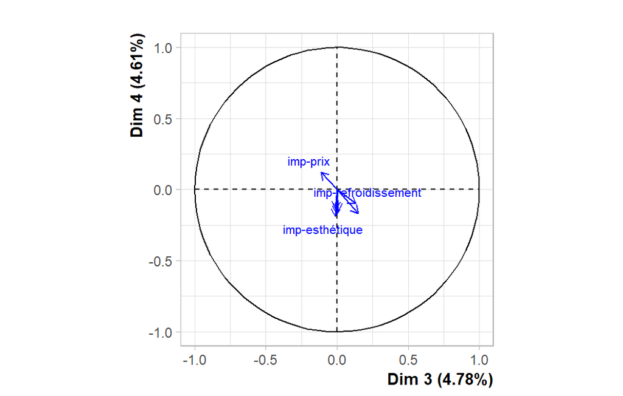

**Figure 4.3 - Graphe des variables quantitatives (ACM)** *Les variables libellées sont celles les mieux représentées sur le plan.*

La **dimension 3** oppose des individus caractérisés par une coordonnée fortement positive sur l’axe (à droite du graphe) à des individus caractérisés par une coordonnée fortement négative sur l’axe (à gauche du graphe).

Le groupe 1 (caractérisés par une coordonnée positive sur l’axe) partage :

- une forte fréquence des modalités *type-cylindrée=250-400*, *critère-esthétique=ressemble à une moto*, *sexe=homme*, *âge=30-39 ans*, *type-utilisation=professionnel*, *CSP=ouvrier*, *note-satisfaction=10* et *CSP=classe moyenne* (du plus commun au plus rare).
- une faible fréquence des modalités telles que *critère-esthétique=discret / sobre*, *âge=25-29 ans*, *type-cylindrée=125*, *sexe=femme*, *type-cylindrée=150-200*, *note-satisfaction=7*, *type-cylindrée=100*, *type-utilisation=domicile-travail*, *CSP=employé* et *critère-esthétique=à la mode* (du plus rare au plus commun).

Le groupe 2 (caractérisés par une coordonnées négative sur l’axe) partage :

- une forte fréquence des modalités *sexe=femme*, *critère-esthétique=à la mode*, *type-utilisation=domicile-travail*, *âge=25-29 ans*, *type-cylindrée=125*, *CSP=classe moyenne*, *critère-esthétique=innovant nouveau*, *CSP=employé*, *critère-esthétique=sportif* et *type-cylindrée=150-200* (du plus commun au plus rare).
- une faible fréquence des modalités *type-cylindrée=250-400*, *sexe=homme*, *âge=50 et +*, *critère-esthétique=discret / sobre*, *type-utilisation=personnels et loisirs*, *critère-esthétique=ressemble à une moto*, *CSP=classe supérieure moyenne*, *CSP=classe supérieure* et *critère-esthétique=classique* (du plus rare au plus commun).

La **dimension 4** oppose des individus caractérisés par une coordonnée fortement positive sur l’axe (en haut du graphe) à des individus caractérisés par une coordonnée fortement négative sur l’axe (en bas du graphe).

Le groupe 1 (caractérisés par une coordonnée positive sur l’axe) partage :

- une forte fréquence des modalités *critère-esthétique=discret / sobre*, *CSP=classe supérieure*, *âge=50 et +*, *note-satisfaction=7*, *critère-esthétique=rétro*, *type-cylindrée=100*, *CSP=classe supérieure moyenne* et *type-utilisation=personnels et loisirs* (du plus commun au plus rare).
- une faible fréquence des modalités *CSP=classe moyenne*, *type-cylindrée=250-400*, *critère-esthétique=à la mode*, *note-satisfaction=10*, *critère-esthétique=ressemble à une moto*, *critère-esthétique=sportif*, *critère-esthétique=innovant nouveau*, *âge=30-39 ans*, *CSP=ouvrier* et *type-utilisation=domicile-travail* (du plus rare au plus commun).

Le groupe 2 (caractérisés par une coordonnées négative sur l’axe) partage :

- une forte fréquence des modalités *sexe=femme*, *critère-esthétique=à la mode*, *type-utilisation=domicile-travail*, *âge=25-29 ans*, *type-cylindrée=125*, *CSP=classe moyenne*, *critère-esthétique=innovant nouveau*, *CSP=employé*, *critère-esthétique=sportif* et *type-cylindrée=150-200* (du plus commun au plus rare).
- une faible fréquence des modalités *type-cylindrée=250-400*, *sexe=homme*, *âge=50 et +*, *critère-esthétique=discret / sobre*, *type-utilisation=personnels et loisirs*, *critère-esthétique=ressemble à une moto*, *CSP=classe supérieure moyenne*, *CSP=classe supérieure* et *critère-esthétique=classique* (du plus rare au plus commun).

Le groupe 3 (caractérisés par une coordonnées négative sur l’axe) partage :

- une forte fréquence des modalités *type-cylindrée=250-400*, *critère-esthétique=ressemble à une moto*, *sexe=homme*, *âge=30-39 ans*, *type-utilisation=professionnel*, *CSP=ouvrier*, *note-satisfaction=10* et *CSP=classe moyenne* (du plus commun au plus rare).
- une faible fréquence des modalités telles que *critère-esthétique=discret / sobre*, *âge=25-29 ans*, *type-cylindrée=125*, *sexe=femme*, *type-cylindrée=150-200*, *note-satisfaction=7*, *type-cylindrée=100*, *type-utilisation=domicile-travail*, *CSP=employé* et *critère-esthétique=à la mode* (du plus rare au plus commun).

### 5. Description du plan 5:6

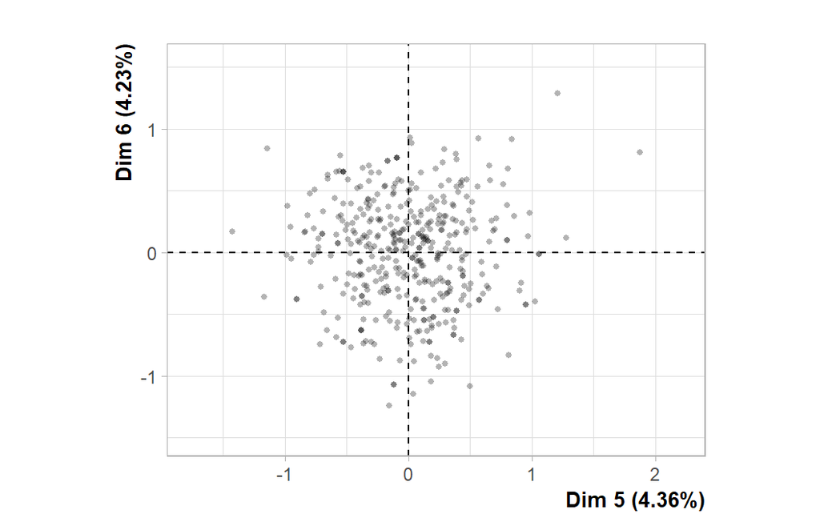

**Figure 5.1 - Graphe des individus (ACM)** *Les individus libellés sont ceux ayant la plus grande contribution à la construction du plan.*

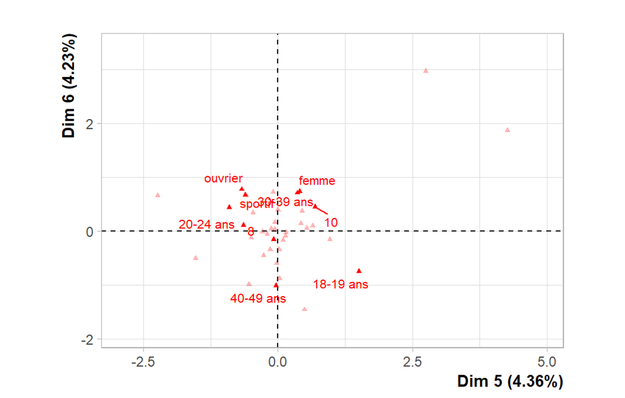

**Figure 5.2 - Graphe des variables (ACM)** *Les variables libellées sont celles les mieux représentées sur le plan.*

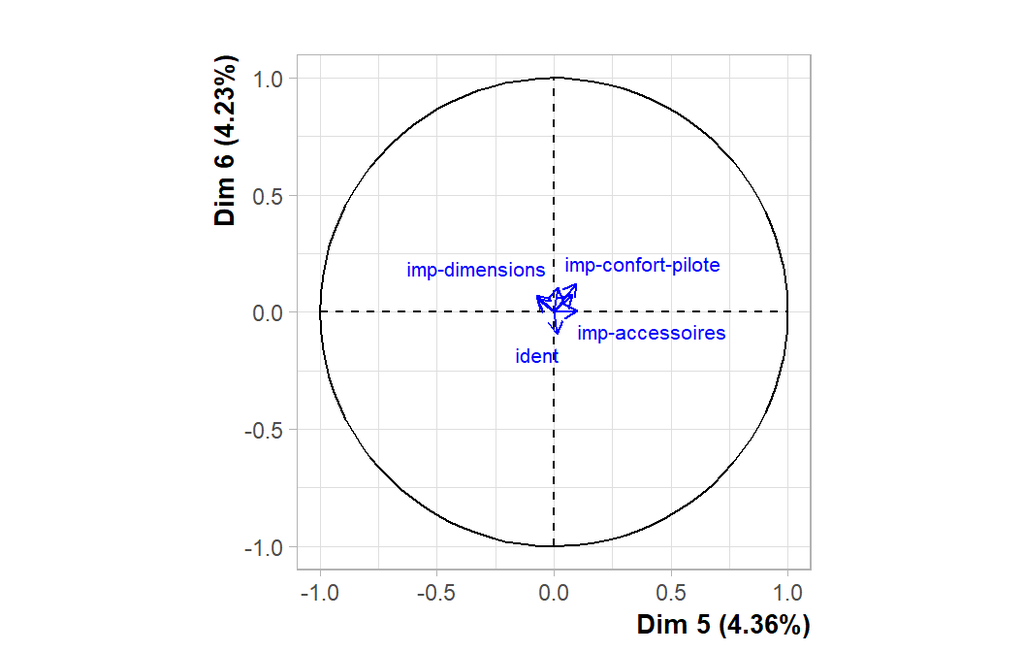

**Figure 5.3 - Graphe des variables quantitatives (ACM)** *Les variables libellées sont celles les mieux représentées sur le plan.*

La **dimension 5** oppose des individus caractérisés par une coordonnée fortement positive sur l’axe (à droite du graphe) à des individus caractérisés par une coordonnée fortement négative sur l’axe (à gauche du graphe).

Le groupe 1 (caractérisés par une coordonnée positive sur l’axe) partage :

- une forte fréquence des modalités *note-satisfaction=10*, *note-satisfaction=9*, *type-cylindrée=250-400*, *critère-esthétique=à la mode*, *sexe=femme*, *âge=18-19 ans*, *âge=30-39 ans*, *CSP=employé*, *critère-esthétique=discret / sobre* et *type-utilisation=personnels et loisirs* (du plus commun au plus rare).
- une faible fréquence des modalités telles que *note-satisfaction=8*, *sexe=homme*, *âge=20-24 ans*, *type-cylindrée=150-200*, *note-satisfaction=7*, *âge=40-49 ans*, *critère-esthétique=innovant nouveau*, *critère-esthétique=sportif*, *CSP=ouvrier* et *type-utilisation=domicile-travail* (du plus rare au plus commun).

Le groupe 2 (caractérisés par une coordonnées négative sur l’axe) partage :

- une forte fréquence des modalités *critère-esthétique=sportif*, *note-satisfaction=8*, *âge=20-24 ans*, *CSP=ouvrier*, *critère-esthétique=rétro*, *type-utilisation=domicile-travail*, *type-cylindrée=125* et *âge=16-17 ans* (du plus commun au plus rare).
- une faible fréquence des modalités telles que *âge=40-49 ans*, *critère-esthétique=à la mode*, *CSP=classe moyenne*, *type-cylindrée=250-400*, *note-satisfaction=7*, *âge=18-19 ans*, *critère-esthétique=discret / sobre*, *CSP=employé*, *critère-esthétique=innovant nouveau* et *type-utilisation=personnels et loisirs* (du plus rare au plus commun).

La **dimension 6** oppose des individus caractérisés par une coordonnée fortement positive sur l’axe (en haut du graphe) à des individus caractérisés par une coordonnée fortement négative sur l’axe (en bas du graphe).

Le groupe 1 (caractérisés par une coordonnée positive sur l’axe) partage :

- une forte fréquence des modalités *critère-esthétique=sportif*, *note-satisfaction=8*, *âge=20-24 ans*, *CSP=ouvrier*, *critère-esthétique=rétro*, *type-utilisation=domicile-travail*, *type-cylindrée=125* et *âge=16-17 ans* (du plus commun au plus rare).
- une faible fréquence des modalités telles que *âge=40-49 ans*, *critère-esthétique=à la mode*, *CSP=classe moyenne*, *type-cylindrée=250-400*, *note-satisfaction=7*, *âge=18-19 ans*, *critère-esthétique=discret / sobre*, *CSP=employé*, *critère-esthétique=innovant nouveau* et *type-utilisation=personnels et loisirs* (du plus rare au plus commun).

Le groupe 2 (caractérisés par une coordonnée positive sur l’axe) partage :

- une forte fréquence des modalités *note-satisfaction=10*, *note-satisfaction=9*, *type-cylindrée=250-400*, *critère-esthétique=à la mode*, *sexe=femme*, *âge=18-19 ans*, *âge=30-39 ans*, *CSP=employé*, *critère-esthétique=discret / sobre* et *type-utilisation=personnels et loisirs* (du plus commun au plus rare).
- une faible fréquence des modalités telles que *note-satisfaction=8*, *sexe=homme*, *âge=20-24 ans*, *type-cylindrée=150-200*, *note-satisfaction=7*, *âge=40-49 ans*, *critère-esthétique=innovant nouveau*, *critère-esthétique=sportif*, *CSP=ouvrier* et *type-utilisation=domicile-travail* (du plus rare au plus commun).

Le groupe 3 (caractérisés par une coordonnées négative sur l’axe) partage :

- une forte fréquence des modalités *âge=40-49 ans*, *CSP=classe moyenne*, *note-satisfaction=7*, *critère-esthétique=innovant nouveau*, *sexe=homme*, *note-satisfaction=6* et *âge=50 et +* (du plus commun au plus rare).
- une faible fréquence des modalités *âge=30-39 ans*, *critère-esthétique=sportif*, *sexe=femme*, *CSP=ouvrier*, *note-satisfaction=9*, *note-satisfaction=10*, *âge=20-24 ans* et *type-cylindrée=125* (du plus rare au plus commun).

### 6. Description de la dimension 7

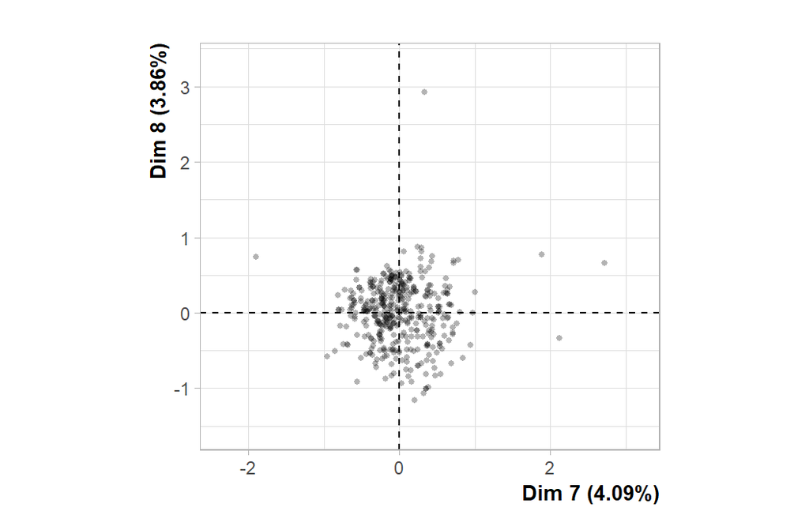

**Figure 6.1 - Graphe des individus (ACM)** *Les individus libellés sont ceux ayant la plus grande contribution à la construction du plan.*

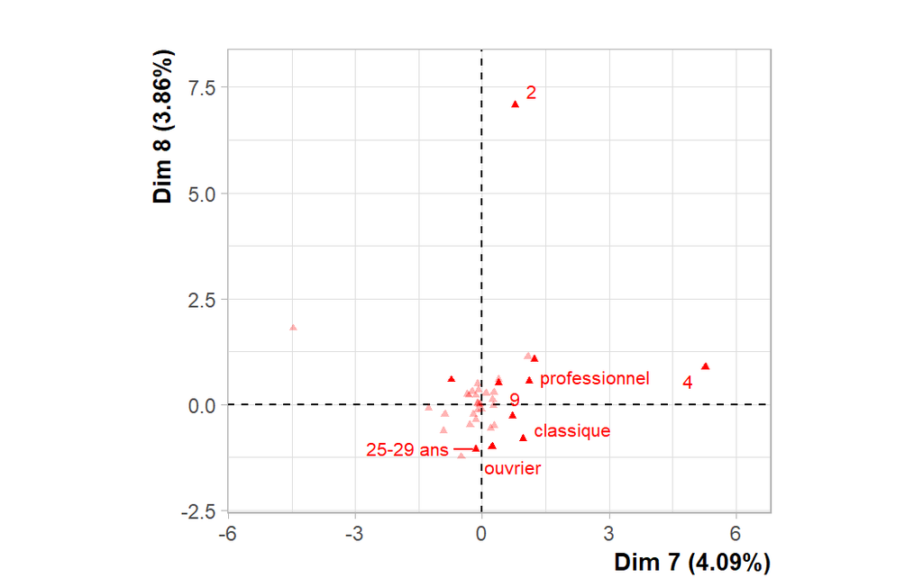

**Figure 6.2 - Graphe des variables (ACM)** *Les variables libellées sont celles les mieux représentées sur le plan.*

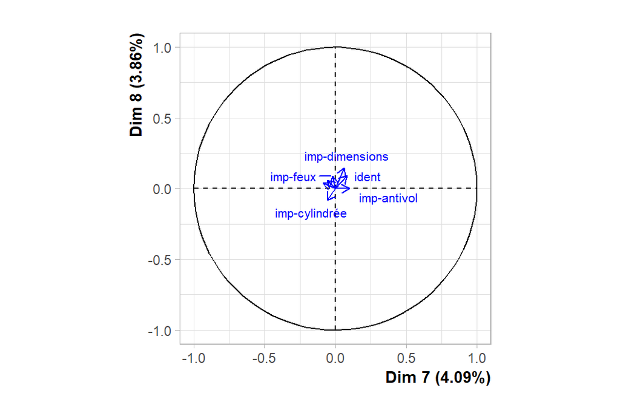

**Figure 6.3 - Graphe des variables quantitatives (ACM)** *Les variables libellées sont celles les mieux représentées sur le plan.*

La **dimension 7** oppose des individus caractérisés par une coordonnée fortement positive sur l’axe (à droite du graphe) à des individus caractérisés par une coordonnée fortement négative sur l’axe (à gauche du graphe).

Le groupe 1 (caractérisés par une coordonnée positive sur l’axe) partage :

- une forte fréquence des modalités *critère-esthétique=classique*, *note-satisfaction=9*, *critère-esthétique=à la mode*, *CSP=ouvrier*, *âge=50 et +* et *âge=25-29 ans* (du plus commun au plus rare).
- une faible fréquence des modalités *note-satisfaction=8*, *critère-esthétique=discret / sobre*, *critère-esthétique=innovant nouveau*, *CSP=classe moyenne*, *critère-esthétique=sportif*, *âge=30-39 ans*, *âge=40-49 ans*, *CSP=classe supérieure* et *note-satisfaction=10* (du plus rare au plus commun).

Le groupe 2 (caractérisés par une coordonnée positive sur l’axe) partage :

- une forte fréquence des modalités *CSP=classe supérieure moyenne*, *type-utilisation=professionnel*, *âge=40-49 ans* et *note-satisfaction=4* (du plus commun au plus rare).
- une faible fréquence des modalités *âge=25-29 ans*, *CSP=employé*, *CSP=classe supérieure* et *CSP=ouvrier* (du plus rare au plus commun).

Le groupe 3 (caractérisés par une coordonnées négative sur l’axe) partage :

- une forte fréquence des modalités *note-satisfaction=8*, *critère-esthétique=discret / sobre*, *CSP=classe supérieure*, *CSP=classe moyenne*, *âge=30-39 ans*, *critère-esthétique=innovant nouveau*, *critère-esthétique=ressemble à une moto*, *note-satisfaction=10* et *sexe=homme* (du plus commun au plus rare).
- une faible fréquence des modalités *critère-esthétique=classique*, *note-satisfaction=9*, *CSP=classe supérieure moyenne*, *type-utilisation=professionnel*, *critère-esthétique=à la mode*, *CSP=ouvrier* et *sexe=femme* (du plus rare au plus commun).

### 7. Classification

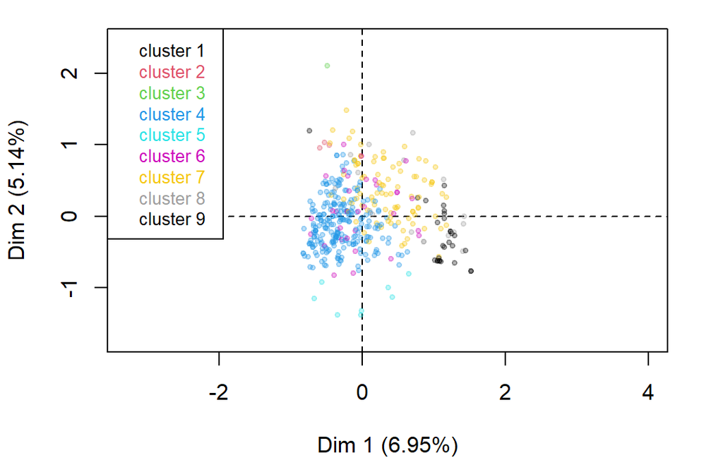

**Figure 7 - Classification Ascendante Hiérachique des individus.** *La classification réalisée sur les individus fait apparaître 9 clusters.*

La classe 1 est composé d’individus partageant :

- une forte fréquence de la modalité *note-satisfaction=2*.

La classe 2 est composé d’individus partageant :

- une forte fréquence de la modalité *note-satisfaction=4*.

La classe 3 est composé d’individus partageant :

- une forte fréquence de la modalité *note-satisfaction=3*.

La classe 4 est composé d’individus partageant :

- une forte fréquence des modalités telles que *CSP=classe moyenne*, *type-cylindrée=250-400*, *âge=40-49 ans*, *CSP=classe supérieure moyenne*, *critère-esthétique=innovant nouveau*, *type-utilisation=domicile-travail*, *âge=30-39 ans*, *CSP=classe supérieure*, *type-cylindrée=150-200* et *CSP=employé* (du plus commun au plus rare).
- une faible fréquence des modalités telles que *CSP=inactif*, *âge=20-24 ans*, *CSP=ouvrier*, *âge=18-19 ans*, *type-cylindrée=100*, *critère-esthétique=ressemble à une moto*, *note-satisfaction=6*, *âge=16-17 ans*, *note-satisfaction=5* et *type-utilisation=personnels et loisirs* (du plus rare au plus commun).

La classe 5 est composé d’individus partageant :

- une forte fréquence des modalités *critère-esthétique=rétro* et *type-cylindrée=150-200* (du plus commun au plus rare).

La classe 6 est composé d’individus partageant :

- une forte fréquence des modalités *note-satisfaction=6* et *critère-esthétique=ressemble à une moto* (du plus commun au plus rare).
- une faible fréquence des modalités *note-satisfaction=8*, *critère-esthétique=sportif* et *critère-esthétique=innovant nouveau* (du plus rare au plus commun).

La classe 7 est composé d’individus partageant :

- une forte fréquence des modalités *âge=20-24 ans*, *CSP=ouvrier*, *type-cylindrée=100*, *CSP=inactif*, *critère-esthétique=sportif*, *note-satisfaction=8*, *type-utilisation=professionnel* et *sexe=femme* (du plus commun au plus rare).
- une faible fréquence des modalités telles que *âge=40-49 ans*, *type-cylindrée=250-400*, *CSP=classe moyenne*, *CSP=classe supérieure moyenne*, *CSP=classe supérieure*, *âge=18-19 ans*, *critère-esthétique=ressemble à une moto*, *note-satisfaction=6*, *type-cylindrée=150-200* et *CSP=employé* (du plus rare au plus commun).

La classe 9 est composé d’individus partageant :

- une forte fréquence des modalités *âge=18-19 ans*, *CSP=inactif*, *type-utilisation=personnels et loisirs*, *type-cylindrée=125* et *critère-esthétique=à la mode* (du plus commun au plus rare).
- une faible fréquence des modalités telles que *âge=30-39 ans*, *type-utilisation=domicile-travail*, *CSP=classe moyenne*, *type-cylindrée=150-200*, *âge=40-49 ans*, *âge=25-29 ans*, *CSP=employé*, *âge=20-24 ans*, *CSP=classe supérieure moyenne* et *type-cylindrée=250-400* (du plus rare au plus commun).